# R Notebook

# Logistic regression lab

### Section 1: Learning Objectives

1. Practice performing logistic regression
2. Extract and interpret fitted coefficients
3. Calculate and plot ROC curves and the AUC
4. Compare classifiers based on different logistic regressions

### Section 1: MVP

You’re given sample data for the customers of a **telecomms company**, and asked to use the data to build a classifier to predict which customers are likely to ‘churn’ (i.e. decline to renew their service contract and move to another supplier) over the next 12 months. **Your clients intend to use your classifier to send targeted offers to customers likely to churn.**

The sample data given in file telecomms_churn.xlsx contains a number of columns, including a Churn column stating whether each customer churned during the previous 12 months.

```r
telecoms <- read_xlsx("data/telecomms_churn.xlsx")
```

[output not shown]

```r
summary(telecoms)
```

```
 customer_id           gender          senior_citizen
 Length:7043        Length:7043        Min.   :0.0000
 Class :character   Class :character   1st Qu.:0.0000
 Mode  :character   Mode  :character   Median :0.0000
                                       Mean   :0.1621
                                       3rd Qu.:0.0000
                                       Max.   :1.0000

   partner           dependents            tenure
 Length:7043        Length:7043        Min.   : 0.00
 Class :character   Class :character   1st Qu.: 9.00
 Mode  :character   Mode  :character   Median :29.00
                                       Mean   :32.37
                                       3rd Qu.:55.00
                                       Max.   :72.00

 phone_service      internet_service     contract
 Length:7043        Length:7043        Length:7043
 Class :character   Class :character   Class :character
 Mode  :character   Mode  :character   Mode  :character




 monthly_charges  total_charges       churn
 Min.   : 18.25   Min.   :  18.8   Length:7043
 1st Qu.: 35.50   1st Qu.: 401.4   Class :character
 Median : 70.35   Median :1397.5   Mode  :character
 Mean   : 64.76   Mean   :2283.3
 3rd Qu.: 89.85   3rd Qu.:3794.7
 Max.   :118.75   Max.   :8684.8
                  NA's   :11
```

We replace the NAs from the total_charges variable by the mean value of that variable

```r
summary(telecoms)
```

```
 customer_id           gender          senior_citizen
 Length:7043        Length:7043        Min.   :0.0000
 Class :character   Class :character   1st Qu.:0.0000
 Mode  :character   Mode  :character   Median :0.0000
                                       Mean   :0.1621
                                       3rd Qu.:0.0000
                                       Max.   :1.0000
   partner           dependents            tenure
 Length:7043        Length:7043        Min.   : 0.00
 Class :character   Class :character   1st Qu.: 9.00
 Mode  :character   Mode  :character   Median :29.00
                                       Mean   :32.37
                                       3rd Qu.:55.00
                                       Max.   :72.00
 phone_service      internet_service     contract
 Length:7043        Length:7043        Length:7043
 Class :character   Class :character   Class :character
 Mode  :character   Mode  :character   Mode  :character



 monthly_charges  total_charges       churn
 Min.   : 18.25   Min.   :  18.8   Length:7043
 1st Qu.: 35.50   1st Qu.: 402.2   Class :character
 Median : 70.35   Median :1400.5   Mode  :character
 Mean   : 64.76   Mean   :2283.3
 3rd Qu.: 89.85   3rd Qu.:3786.6
 Max.   :118.75   Max.   :8684.8
```

Examine the relationships between the churn variable and other possible predictor variables, looking for significant relationships.

```r
library(GGally)
```

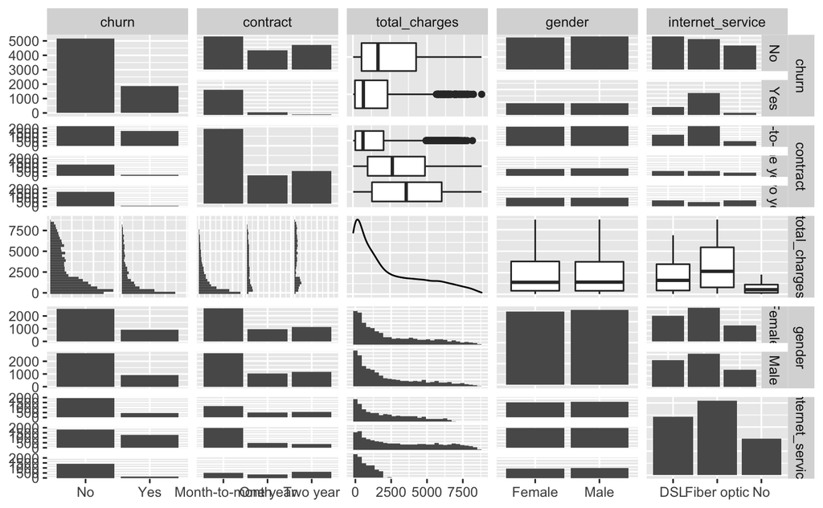

As shown from the above plot, the churn variable seems to be affected by the variable **total charges**, **internet service** and **contract**.

We plot the total charges with respect to the churn. It it clear to see that customers with higher total charges are likely to renew their contract.

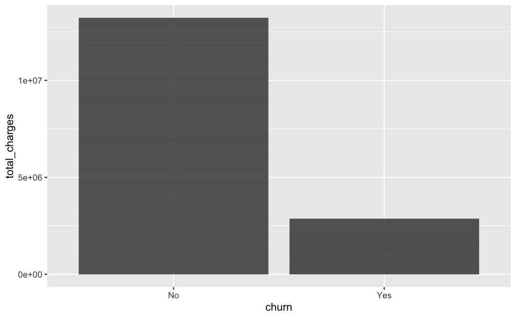

It is also seen that montly charges and total charges are correlated. Therefore, in the study we will only deal with the total charges variable.

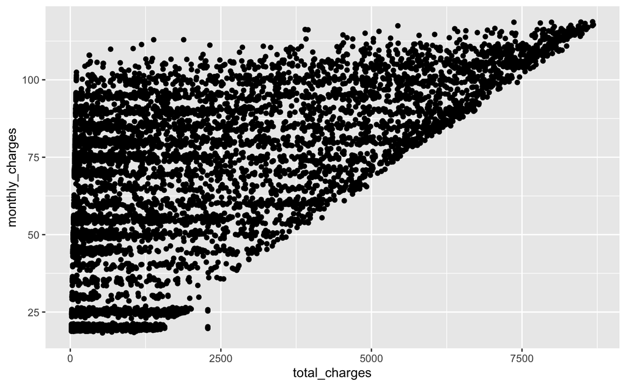

| cor(total_charges, monthly_charges) |
| --- |
| 0.650468 |

Convert all character columns to factor columns (hint consider mutate_if() for this). Convert senior_citizen to a meaningful factor column as well.

We also rename the churn variable and call it “renew”. This variable gives TRUE if customers renew their contract.

```r
telecoms_new_logical <- telecoms_new%>%
  mutate(renew = ifelse(churn == "No", TRUE, FALSE))
```

Let’s plto the **renew** variable with respect to **total_charges.**

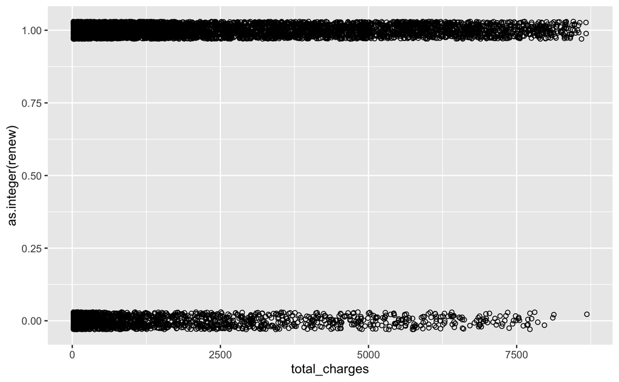

As shown, it is more likely that customers renew their contract if they pay high amount of total charges.

3. Let’s perform logistic regression using the churn column as the binary dependent variable. Create three separate single predictor logistic regression models choosing from amongst the promising predictor columns you found in your analysis above. Try to have at least one continuous predictor, and at least one categorical predictor. Check that the coefficient of the single predictor in each model is statistically significant. **Model 1 with Continous Predictor Variable (total_charges)**

```r
telecoms_logred_model1_continous <- glm(renew ~ total_charges, data = telecoms_new_logical, family = binomial(link = 'logit'))

summary(telecoms_logred_model1_continous)
```

[output not shown]

**Model 2 with Categorical Predictor Variable (internet service)**

```r
telecoms_logred_model2_categorical <- glm(renew ~ internet_service, data = telecoms_new_logical, family = binomial(link = 'logit'))

summary(telecoms_logred_model2_categorical)
```

```
Call:
glm(formula = renew ~ internet_service, family = binomial(link = "logit"),
    data = telecoms_new_logical)

Deviance Residuals:
    Min       1Q   Median       3Q      Max
-2.2817  -1.3191   0.6484   1.0420   1.0420

Coefficients:
                            Estimate Std. Error z value Pr(>|z|)
(Intercept)                  1.45267    0.05185   28.02   <2e-16 ***
internet_serviceFiber optic -1.12549    0.06337  -17.76   <2e-16 ***
internet_serviceNo           1.07341    0.11066    9.70   <2e-16 ***
---
Signif. codes:  0 ‘***’ 0.001 ‘**’ 0.01 ‘*’ 0.05 ‘.’ 0.1 ‘ ’ 1

(Dispersion parameter for binomial family taken to be 1)

    Null deviance: 8150.1  on 7042  degrees of freedom
Residual deviance: 7367.3  on 7040  degrees of freedom
AIC: 7373.3

Number of Fisher Scoring iterations: 5
```

**Model 3 with Categorical Predictor Variable (contract)**

```r
telecoms_logred_model3_categorical <- glm(renew ~ contract, data = telecoms_new_logical, family = binomial(link = 'logit'))

summary(telecoms_logred_model3_categorical)
```

```
Call:
glm(formula = renew ~ contract, family = binomial(link = "logit"),
    data = telecoms_new_logical)

Deviance Residuals:
   Min      1Q  Median      3Q     Max
-2.670  -1.304   0.489   1.056   1.056

Coefficients:
                 Estimate Std. Error z value Pr(>|z|)
(Intercept)       0.29371    0.03248   9.044   <2e-16 ***
contractOne year  1.76980    0.08857  19.983   <2e-16 ***
contractTwo year  3.24180    0.14998  21.614   <2e-16 ***
---
Signif. codes:  0 ‘***’ 0.001 ‘**’ 0.01 ‘*’ 0.05 ‘.’ 0.1 ‘ ’ 1

(Dispersion parameter for binomial family taken to be 1)

    Null deviance: 8150.1  on 7042  degrees of freedom
Residual deviance: 6763.3  on 7040  degrees of freedom
AIC: 6769.3

Number of Fisher Scoring iterations: 6
```

For each of the above models, the coefficients of the single predictor variables are significant as they are all 0.